# Praca domowa 3

Zuzanna Kotlińska i Agata Kopyt

23 11 2021

# Wstęp

Celem naszej pracy było przeprowadzenie dwóch eksperymentów sprawdzających, jak forma wykresu wpływa na jego czytelność. Chciałyśmy przekonać się, czy zastosowanie dobrych praktyk przy tworzeniu wykresów przekonuje osoby niezwiązane z analizą danych. Jednocześnie badałyśmy osoby w wieku 18-25 lat, czyli od dziecka otoczone wykresami i zestawieniami. Czy faktycznie dla przeciętnej osoby wykres jest źródłem informacji czy czymś, co przede wszystkim ma być przyjemne dla oka? Czy jej zdolności odczytywania wykresów są lepsze niż zakładano?

# Część pierwsza

W pierwszym eksperymencie sprawdziłyśmy, czy osoby niezwiązane z analizą danych chętniej wybierają wykres, z którego są w stanie łatwo odczytać informacje, czy ten który wydaje się być bardziej atrakcyjny, lecz mniej czytelny. W zależności, który wykres wybrały, musiały odpowiedzieć na kilka pytań dotyczących danych znajdujących się na nim, między innymi oszacować różnice między określonymi wartościami.

## Wybór wykresu

Ankietowani mieli do wyboru dwa poniżej przedstawione wykresy.

**Wykres 1**

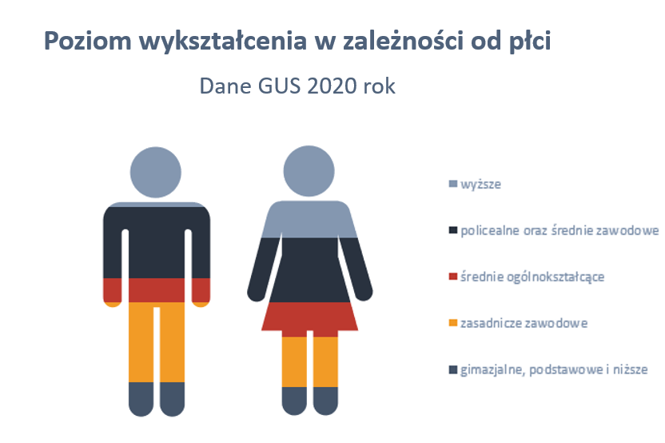

**Wykres 2**

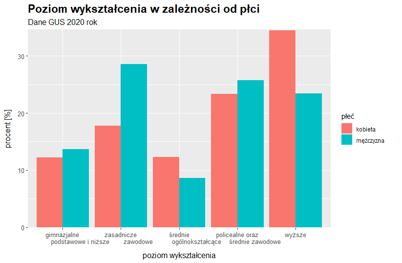

Statystyki prezentują się następująco:

**Wybór wykresu**

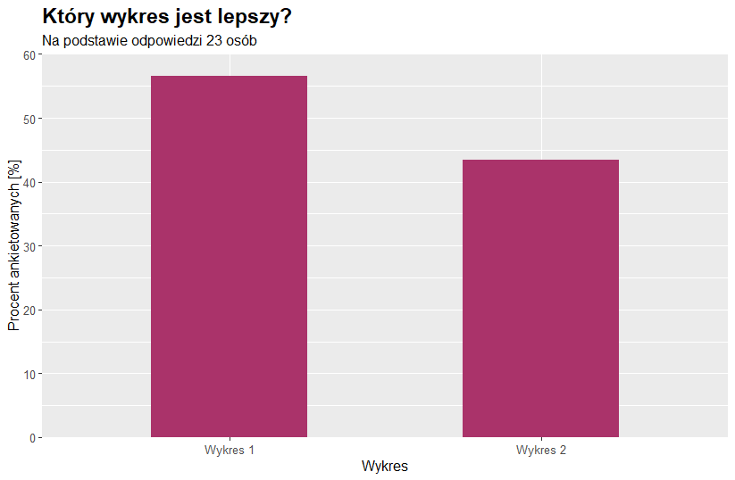

Osoby, które wybrały wykres nr 2 stwierdziły, że jest o wiele bardziej czytelny, łatwiej określić konkretne liczby i odczytać z niego zależności. Jako atut wskazały fakt, że słupki zaczynają się na tym samym poziomie. Zwolennicy wykresu nr 1 przyznają, że jest on mniej szczegółowy, ale bardziej intuicyjny i przykuwa wzrok. Zaletą jest dla nich fakt, że nie trzeba odczytywać informacji z osi, a kolor i płeć są wyraźnie uwidocznione.

Ale czy na pewno intuicja działa w tym wypadku i to, co widzimy na pierwszy rzut oka jest poprawne?

## Pytania

W pierwszym pytaniu należało wskazać, jakie wykształcenie ma największy odsetek kobiet patrząc na wybrany wcześniej wykres.

Prawie połowa osób analizująca wykres nr 1 odpowiedziała źle, wybierając wykształcenie policealne oraz średnie zawodowe. Przy wykresie 2 odpowiedź na to pytanie okazała się być łatwym zadaniem - wszyscy wybrali prawidłową opcję.

**Skuteczność obu grup przy pierwszym pytaniu**

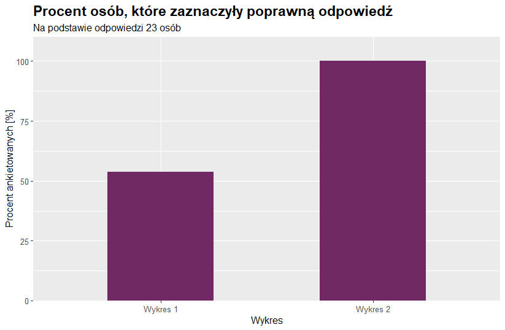

Drugie pytanie polegało na określeniu, która z płci ma większy odsetek osób z wykształceniem policealnym oraz średnim zawodowym. To pytanie nie sprawiło trudności żadnej z grup (w obu przypadkach źle odpowiedziała tylko jedna osoba).

Największe różnice w łatwości odczytywania danych uwidacznia trzecie i czwarte pytanie, gdzie trzeba było szacować wartości. Zdecydowana większość zwolenników wykresu nr 1 odpowiedziała niepoprawnie, a wskazywane przez nich wartości różniły się nawet o 15 punktów procentowych. Osoby, które wybrały wykres nr 2, również popełniały błędy, ale z nieporównywalnie mniejszą częstotliwością.

**Zestawienie odpowiedzi na pytanie 3 dla zwolenników każdego z wykresów:**

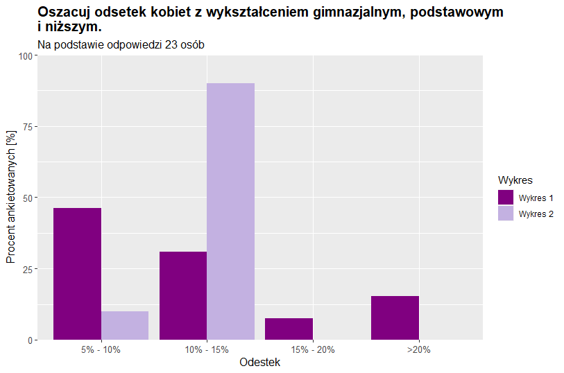

**Procent prawidłowych odpowiedzi na pytanie 3 w obu grupach:**

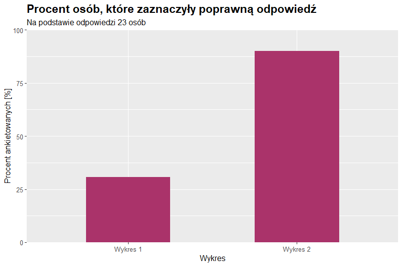

**Zestawienie odpowiedzi na pytanie 4 dla zwolenników każdego z wykresów:**

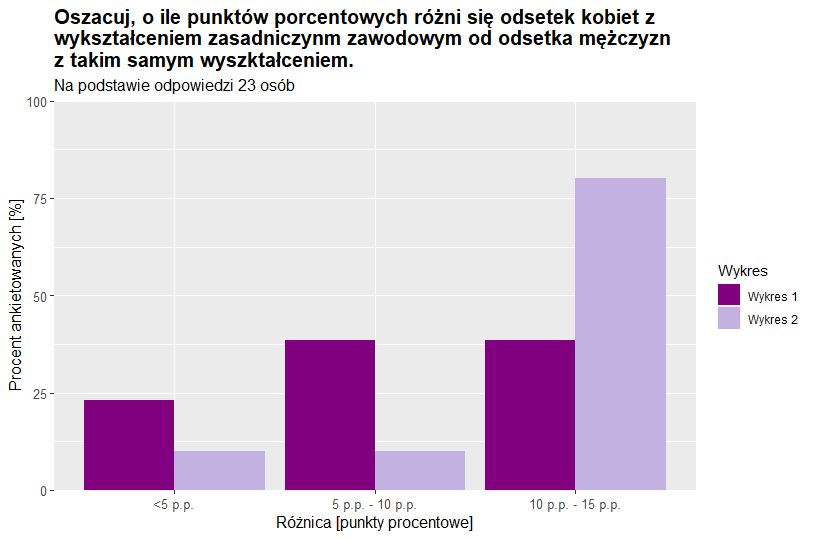

**Procent prawidłowych odpowiedzi na pytanie 4 w obu grupach:**

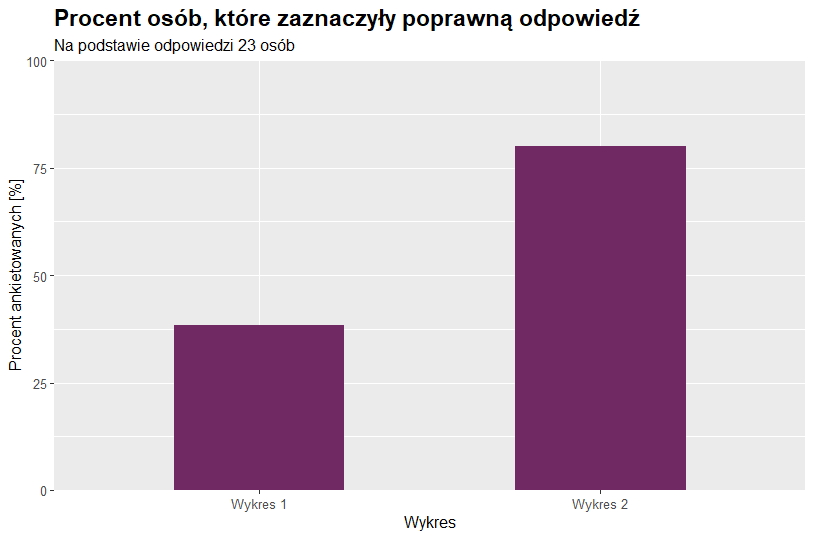

# Część druga

## Pytanie 1

Pierwsze polecenie służyło zbadaniu czy odbiorca jest w stanie poprawnie porównać wartości słupków gdy są od siebie oddalone w porównaniu gdy są zestawione jeden przy drugim. Ankietowani otrzymali następujące wykresy:

**Wykres 1**

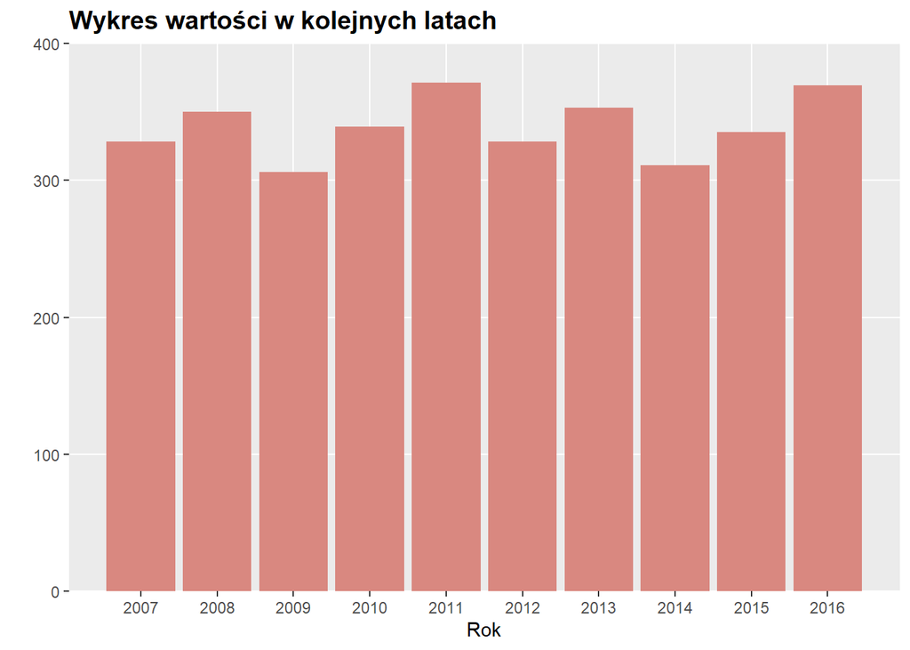

**Wykres 2**

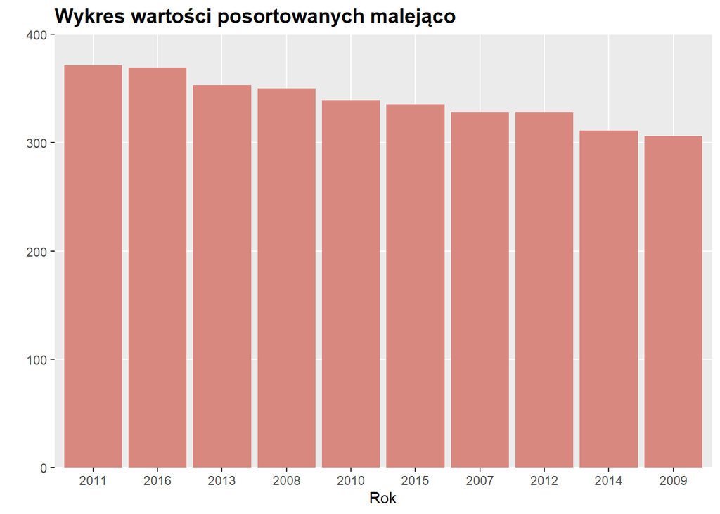

Do obu z nich musieli wybrać wszystkie poprawne odpowiedzi do następującego zadania:

Na podstawie powyższego wykresu wskaż pary lat, dla których słupki mają te same wartości

- 2007 i 2012
- 2008 i 2012
- 2009 i 2014
- 2010 i 2015
- 2011 i 2016
- Takie pary nie istnieją

Poprawną odpowiedzią jest “2007 i 2012”

**Podsumowanie pytania 1 dla wykresu 1**

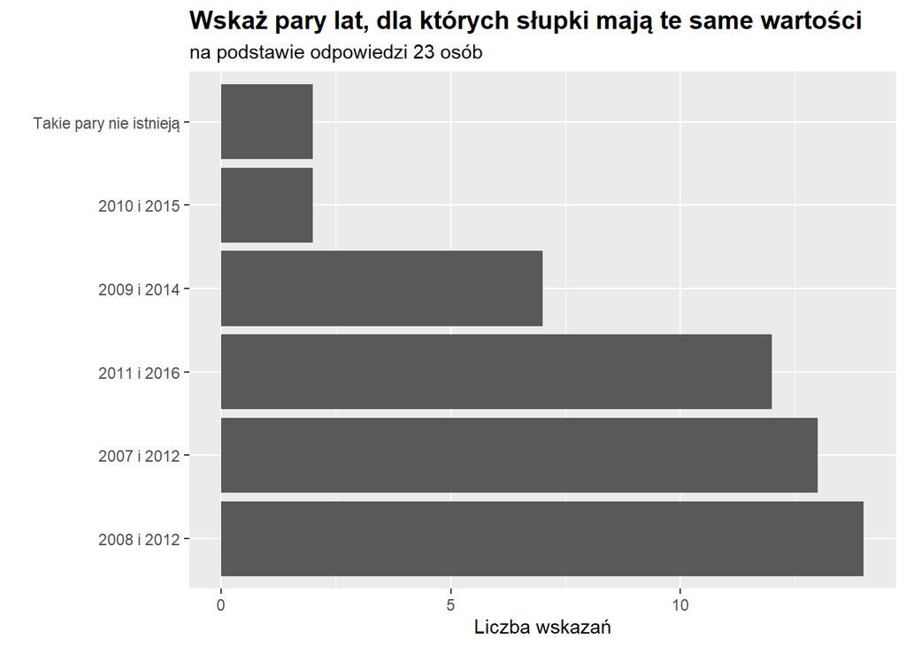

**Podsumowanie pytania 1 dla wykresu 2**

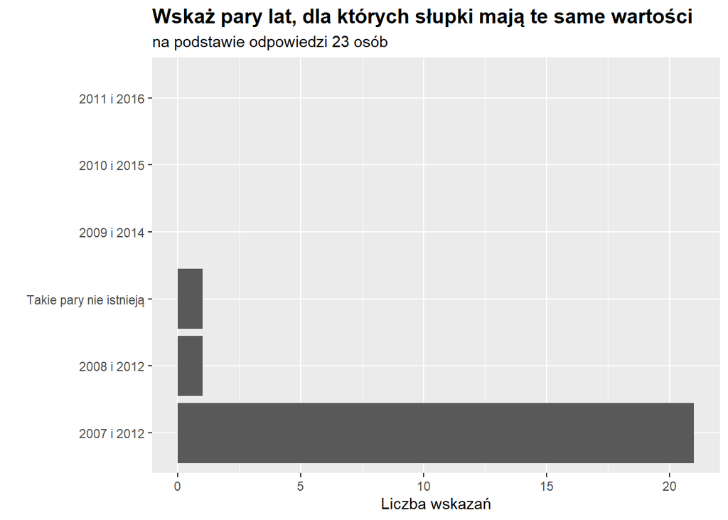

W przypadku wykresu z wartościami posortowanymi malejąco niemal wszyscy ankietowani udzielili poprawnej odpowiedzi, a błędne odpowiedzi zostały wskazane jedynie 2 razy.

### Pytanie 2

W następnym pytaniu badani poproszeni byli o wskazanie wykresu, który ich zdaniem najlepiej obrazuje zmianę wartości na przestrzeni czasu. Możliwymi odpowiedziami były zaprezentowane już wykresy 1 i 2 oraz wykres 3, ukazany poniżej.

**Wykres 3**

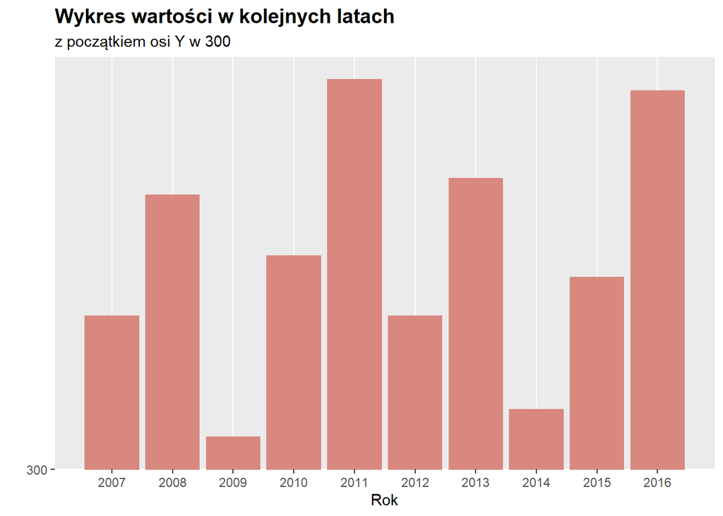

Jest on wycinkiem wykresu 1 od wartości powyżej 300. Ta zmiana zaburzyła wizualne proporcje wykresu.

**Podsumowanie pytania 2**

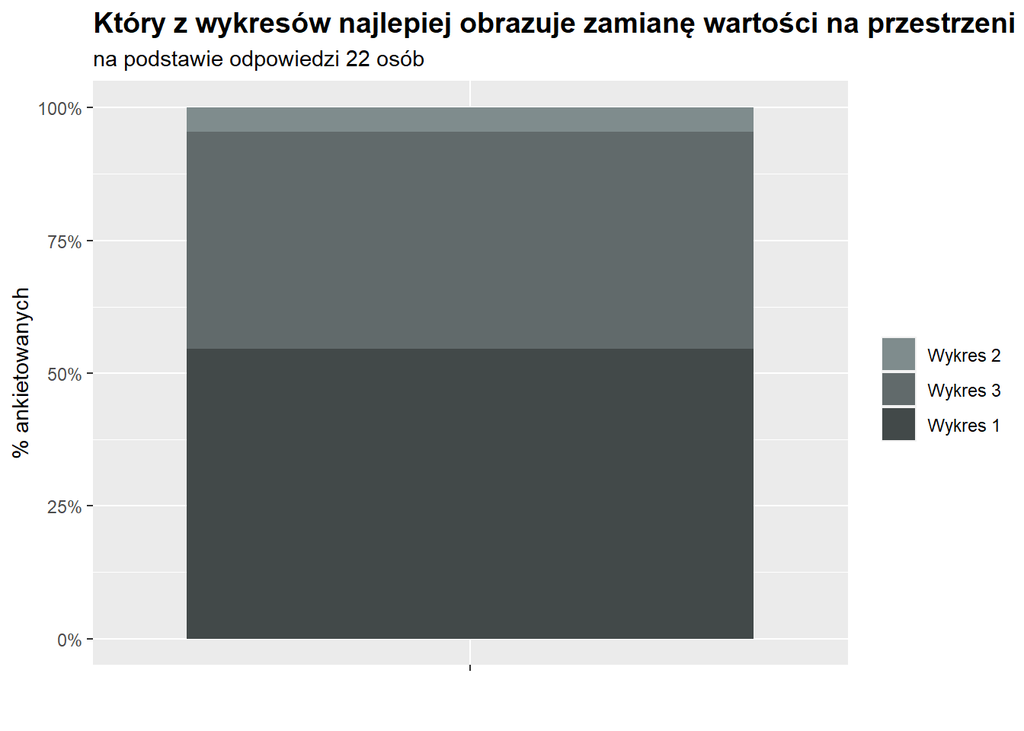

Jak widać większość ankietowanych zdecydowała się na wykres, w którym słupki posegregowane są zgodnie z upływem czasu co wpisuje się w kanon prezentowania tendencji wartości w czasie.

### Pytanie 3

Ostatnie pytanie dotyczyło umiejętności określenia proporcji słupków, gdy skala osi Y nie rozpoczynała się w 0. Pozostała nadzieja, że badani czytając wykres nie zwracają uwagi jedynie na to jak prezentują się słupki, ale na całe ich “środowisko” tworzone przez osie i nie ulegną powszechnie stosowanej manipulacji.

Na podstawie wykresu 3 ankietowani określali ilokrotnie zwiększyła się wartość w roku 2016 względem roku 2015. Poprawna odpowiedź to w przybliżeniu 1,1, natomiast wizualnie słupek dla roku 2016 jest 2 krotnie większy.

**Podsumowanie pytania 3**

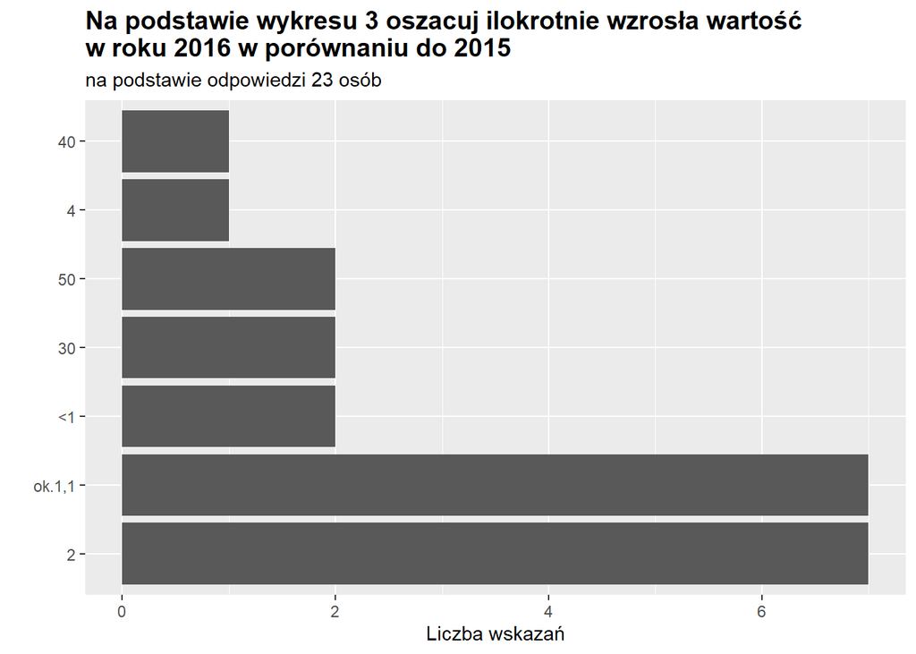

Zaskakująco odpowiedzi poprawnej jak i przewidywanej błędnej udzieliło tyle samo badanych. Odpowiedzi 30,40,50 sugerują, że niektórzy ankietowani podawali o ile w przybliżeniu zmieniła się wartość zamiast ilokrotnie.

## Podsumowanie

Społeczeństwo wciąż kuszą wizualnie atrakcyjne wykresy, chociaż jak wykazało badanie kreują one błędne wyobrażenie o przedstawianych wartościach i przez to nie przekazują poprawnie informacji. Zdecydowanie pozytywnym rezultatem jest fakt, że grupa osób, która wybrała wykres obiektywnie przekazujący informacje była niewiele mniejsza od tej, która wybrała wykres wprowadzający w błąd.

Natomiast dla wykresów słupkowych praktyka aranżacji słupków według wartości potwierdziła się dla wykresów mających na celu zwrócenie uwagi odbiorcy na porównywanie wartości. Ankietowani nie radzili sobie z precyzyjnym porównaniem odległych słupków o podobnych wartościach. Gdy chcemy wskazać przebieg tendencji w okresie czasu, odpowiedzi udzielone przez ankietowanych wskazują, że należy słupki posortować względem daty, rosnąco. Dla pewności poprawnego odbioru proporcji słupków zalecamy rozpoczynanie skali osi Y w zerze. Jednak fakt, że tyle samo osób udzieliło poprawnej odpowiedzi co “nabrało się” wskazuje, że część społeczeństwa od dziecka obcująca z wykresami coraz lepiej radzi sobie z odczytywaniem wykresów i zwraca uwagę na skalę na osi, co jest obiecującą prognozą na przyszłość.